# Risk Factor Analysis

## Outcome Variable

**Outcome Variable:** swasted

## Predictor Variables

**Intervention Variable:** impsan

**Adjustment Set:**

unadjusted

## Stratifying Variables

The analysis was stratified on these variable(s):

- agecat
- studyid
- country

## Data Summary

| agecat | studyid | country | impsan | swasted | n_cell | n |
| --- | --- | --- | --- | --- | --- | --- |
| Birth | COHORTS | GUATEMALA | 1 | 0 | 37 | 449 |
| Birth | COHORTS | GUATEMALA | 1 | 1 | 6 | 449 |
| Birth | COHORTS | GUATEMALA | 0 | 0 | 378 | 449 |
| Birth | COHORTS | GUATEMALA | 0 | 1 | 28 | 449 |
| Birth | COHORTS | INDIA | 1 | 0 | 1603 | 4461 |
| Birth | COHORTS | INDIA | 1 | 1 | 82 | 4461 |
| Birth | COHORTS | INDIA | 0 | 0 | 2644 | 4461 |
| Birth | COHORTS | INDIA | 0 | 1 | 132 | 4461 |
| Birth | COHORTS | PHILIPPINES | 1 | 0 | 170 | 1126 |
| Birth | COHORTS | PHILIPPINES | 1 | 1 | 7 | 1126 |
| Birth | COHORTS | PHILIPPINES | 0 | 0 | 914 | 1126 |
| Birth | COHORTS | PHILIPPINES | 0 | 1 | 35 | 1126 |
| Birth | CONTENT | PERU | 1 | 0 | 1 | 2 |
| Birth | CONTENT | PERU | 1 | 1 | 0 | 2 |
| Birth | CONTENT | PERU | 0 | 0 | 1 | 2 |
| Birth | CONTENT | PERU | 0 | 1 | 0 | 2 |
| Birth | JiVitA-3 | BANGLADESH | 1 | 0 | 12185 | 17991 |
| Birth | JiVitA-3 | BANGLADESH | 1 | 1 | 228 | 17991 |
| Birth | JiVitA-3 | BANGLADESH | 0 | 0 | 5457 | 17991 |
| Birth | JiVitA-3 | BANGLADESH | 0 | 1 | 121 | 17991 |
| Birth | JiVitA-4 | BANGLADESH | 1 | 0 | 1836 | 2394 |
| Birth | JiVitA-4 | BANGLADESH | 1 | 1 | 23 | 2394 |
| Birth | JiVitA-4 | BANGLADESH | 0 | 0 | 527 | 2394 |
| Birth | JiVitA-4 | BANGLADESH | 0 | 1 | 8 | 2394 |
| Birth | MAL-ED | BANGLADESH | 1 | 0 | 161 | 201 |
| Birth | MAL-ED | BANGLADESH | 1 | 1 | 7 | 201 |
| Birth | MAL-ED | BANGLADESH | 0 | 0 | 32 | 201 |
| Birth | MAL-ED | BANGLADESH | 0 | 1 | 1 | 201 |
| Birth | MAL-ED | BRAZIL | 1 | 0 | 56 | 57 |
| Birth | MAL-ED | BRAZIL | 1 | 1 | 0 | 57 |

[output cut: 170 more lines]

The following strata were considered:

- agecat: 24 months, studyid: COHORTS, country: GUATEMALA
- agecat: 24 months, studyid: COHORTS, country: INDIA
- agecat: 24 months, studyid: COHORTS, country: PHILIPPINES
- agecat: 24 months, studyid: CONTENT, country: PERU
- agecat: 24 months, studyid: JiVitA-3, country: BANGLADESH
- agecat: 24 months, studyid: JiVitA-4, country: BANGLADESH
- agecat: 24 months, studyid: LCNI-5, country: MALAWI
- agecat: 24 months, studyid: MAL-ED, country: BANGLADESH
- agecat: 24 months, studyid: MAL-ED, country: BRAZIL
- agecat: 24 months, studyid: MAL-ED, country: INDIA
- agecat: 24 months, studyid: MAL-ED, country: NEPAL
- agecat: 24 months, studyid: MAL-ED, country: PERU
- agecat: 24 months, studyid: MAL-ED, country: SOUTH AFRICA
- agecat: 24 months, studyid: MAL-ED, country: TANZANIA, UNITED REPUBLIC OF
- agecat: 24 months, studyid: NIH-Birth, country: BANGLADESH
- agecat: 24 months, studyid: NIH-Crypto, country: BANGLADESH
- agecat: 24 months, studyid: PROVIDE, country: BANGLADESH
- agecat: 6 months, studyid: COHORTS, country: GUATEMALA
- agecat: 6 months, studyid: COHORTS, country: INDIA
- agecat: 6 months, studyid: COHORTS, country: PHILIPPINES
- agecat: 6 months, studyid: CONTENT, country: PERU
- agecat: 6 months, studyid: JiVitA-3, country: BANGLADESH
- agecat: 6 months, studyid: JiVitA-4, country: BANGLADESH
- agecat: 6 months, studyid: LCNI-5, country: MALAWI
- agecat: 6 months, studyid: MAL-ED, country: BANGLADESH
- agecat: 6 months, studyid: MAL-ED, country: BRAZIL
- agecat: 6 months, studyid: MAL-ED, country: INDIA
- agecat: 6 months, studyid: MAL-ED, country: NEPAL
- agecat: 6 months, studyid: MAL-ED, country: PERU
- agecat: 6 months, studyid: MAL-ED, country: SOUTH AFRICA
- agecat: 6 months, studyid: MAL-ED, country: TANZANIA, UNITED REPUBLIC OF
- agecat: 6 months, studyid: NIH-Birth, country: BANGLADESH
- agecat: 6 months, studyid: NIH-Crypto, country: BANGLADESH
- agecat: 6 months, studyid: PROVIDE, country: BANGLADESH
- agecat: Birth, studyid: COHORTS, country: GUATEMALA
- agecat: Birth, studyid: COHORTS, country: INDIA
- agecat: Birth, studyid: COHORTS, country: PHILIPPINES
- agecat: Birth, studyid: CONTENT, country: PERU
- agecat: Birth, studyid: JiVitA-3, country: BANGLADESH
- agecat: Birth, studyid: JiVitA-4, country: BANGLADESH
- agecat: Birth, studyid: MAL-ED, country: BANGLADESH
- agecat: Birth, studyid: MAL-ED, country: BRAZIL
- agecat: Birth, studyid: MAL-ED, country: INDIA
- agecat: Birth, studyid: MAL-ED, country: NEPAL
- agecat: Birth, studyid: MAL-ED, country: PERU
- agecat: Birth, studyid: MAL-ED, country: SOUTH AFRICA
- agecat: Birth, studyid: MAL-ED, country: TANZANIA, UNITED REPUBLIC OF
- agecat: Birth, studyid: NIH-Birth, country: BANGLADESH
- agecat: Birth, studyid: NIH-Crypto, country: BANGLADESH
- agecat: Birth, studyid: PROVIDE, country: BANGLADESH

### Dropped Strata

Some strata were dropped due to rare outcomes:

- agecat: Birth, studyid: CONTENT, country: PERU
- agecat: Birth, studyid: MAL-ED, country: BANGLADESH
- agecat: Birth, studyid: MAL-ED, country: BRAZIL
- agecat: Birth, studyid: MAL-ED, country: INDIA
- agecat: Birth, studyid: MAL-ED, country: NEPAL
- agecat: Birth, studyid: MAL-ED, country: PERU
- agecat: Birth, studyid: MAL-ED, country: SOUTH AFRICA
- agecat: Birth, studyid: MAL-ED, country: TANZANIA, UNITED REPUBLIC OF
- agecat: Birth, studyid: PROVIDE, country: BANGLADESH
- agecat: 6 months, studyid: COHORTS, country: GUATEMALA
- agecat: 6 months, studyid: COHORTS, country: PHILIPPINES
- agecat: 6 months, studyid: CONTENT, country: PERU
- agecat: 6 months, studyid: LCNI-5, country: MALAWI
- agecat: 6 months, studyid: MAL-ED, country: BANGLADESH
- agecat: 6 months, studyid: MAL-ED, country: BRAZIL
- agecat: 6 months, studyid: MAL-ED, country: INDIA
- agecat: 6 months, studyid: MAL-ED, country: NEPAL
- agecat: 6 months, studyid: MAL-ED, country: PERU
- agecat: 6 months, studyid: MAL-ED, country: SOUTH AFRICA
- agecat: 6 months, studyid: MAL-ED, country: TANZANIA, UNITED REPUBLIC OF
- agecat: 6 months, studyid: NIH-Birth, country: BANGLADESH
- agecat: 6 months, studyid: NIH-Crypto, country: BANGLADESH
- agecat: 6 months, studyid: PROVIDE, country: BANGLADESH
- agecat: 24 months, studyid: COHORTS, country: GUATEMALA
- agecat: 24 months, studyid: COHORTS, country: PHILIPPINES
- agecat: 24 months, studyid: CONTENT, country: PERU
- agecat: 24 months, studyid: LCNI-5, country: MALAWI
- agecat: 24 months, studyid: MAL-ED, country: BANGLADESH
- agecat: 24 months, studyid: MAL-ED, country: BRAZIL
- agecat: 24 months, studyid: MAL-ED, country: INDIA
- agecat: 24 months, studyid: MAL-ED, country: NEPAL
- agecat: 24 months, studyid: MAL-ED, country: PERU
- agecat: 24 months, studyid: MAL-ED, country: SOUTH AFRICA
- agecat: 24 months, studyid: MAL-ED, country: TANZANIA, UNITED REPUBLIC OF
- agecat: 24 months, studyid: NIH-Birth, country: BANGLADESH
- agecat: 24 months, studyid: NIH-Crypto, country: BANGLADESH
- agecat: 24 months, studyid: PROVIDE, country: BANGLADESH

## Methods Detail

We’re interested in the causal parameters $E[Y_a]$ for all values of $a \in \mathcal{A}$. These parameters represent the mean outcome if, possibly contrary to fact, we intervened to set all units to have $A=a$. Under the randomization and positivity assumptions, these are identified by the statistical parameters $\psi_a=E_W[E_{Y|A,W}(Y|A=a,W)]$. In addition, we’re interested in the mean of $Y$, $E[Y]$ under no intervention (the observed mean). We will estimate these parameters by using SuperLearner to fit the relevant likelihood factors – $E_{Y|A,W}(Y|A=a,W)$ and $p(A=a|W)$, and then updating our likelihood fit using a joint TMLE.

For unadjusted analyses ($W=\{\}$), initial likelihoods were estimated using Lrnr_glm to estimate the simple $E(Y|A)$ and Lrnr_mean to estimate $p(A)$. For adjusted analyses, a small library containing Lrnr_glmnet, Lrnr_xgboost, and Lrnr_mean was used.

Having estimated these parameters, we will then use the delta method to estimate relative risks and attributable risks relative to a prespecified baseline level of $A$.

# Results Detail

## Results Plots

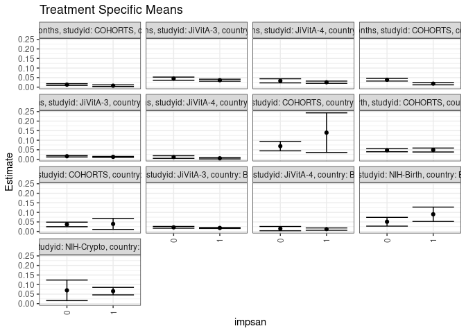

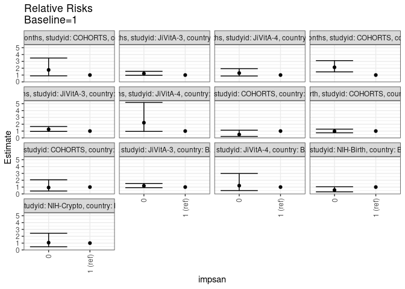

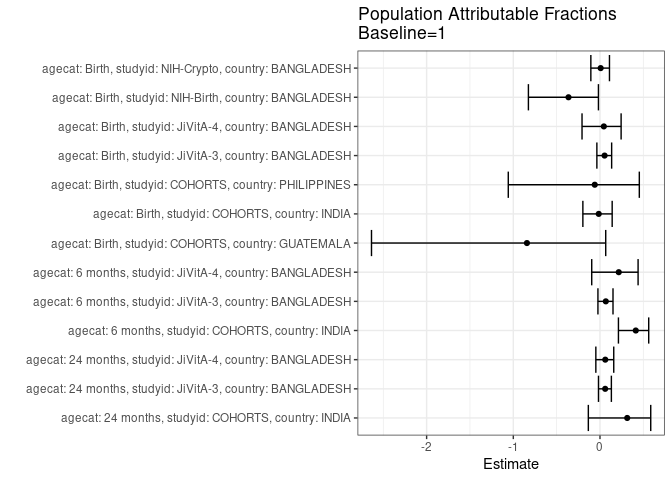

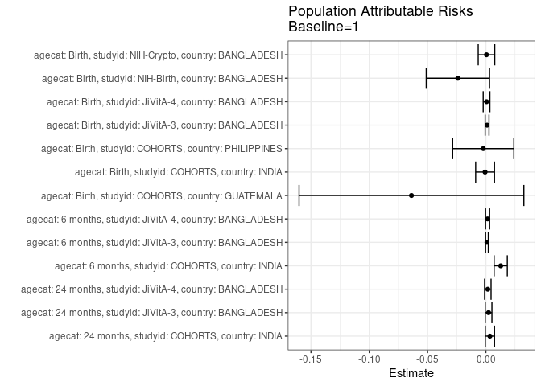

## Results Table

### Parameter: TSM

| agecat | studyid | country | intervention_level | baseline_level | estimate | ci_lower | ci_upper |
| --- | --- | --- | --- | --- | --- | --- | --- |
| Birth | COHORTS | GUATEMALA | 1 | NA | 0.1395349 | 0.0358522 | 0.2432175 |
| Birth | COHORTS | GUATEMALA | 0 | NA | 0.0689655 | 0.0442899 | 0.0936411 |
| Birth | COHORTS | INDIA | 1 | NA | 0.0486647 | 0.0383900 | 0.0589394 |
| Birth | COHORTS | INDIA | 0 | NA | 0.0475504 | 0.0396330 | 0.0554679 |
| Birth | COHORTS | PHILIPPINES | 1 | NA | 0.0395480 | 0.0108234 | 0.0682727 |
| Birth | COHORTS | PHILIPPINES | 0 | NA | 0.0368809 | 0.0248846 | 0.0488773 |
| Birth | JiVitA-3 | BANGLADESH | 1 | NA | 0.0183678 | 0.0156028 | 0.0211329 |
| Birth | JiVitA-3 | BANGLADESH | 0 | NA | 0.0216924 | 0.0170537 | 0.0263310 |
| Birth | JiVitA-4 | BANGLADESH | 1 | NA | 0.0123722 | 0.0061302 | 0.0186143 |
| Birth | JiVitA-4 | BANGLADESH | 0 | NA | 0.0149533 | 0.0037914 | 0.0261151 |
| Birth | NIH-Birth | BANGLADESH | 1 | NA | 0.0900901 | 0.0523948 | 0.1277854 |
| Birth | NIH-Birth | BANGLADESH | 0 | NA | 0.0509915 | 0.0280235 | 0.0739595 |
| Birth | NIH-Crypto | BANGLADESH | 1 | NA | 0.0655738 | 0.0459161 | 0.0852315 |
| Birth | NIH-Crypto | BANGLADESH | 0 | NA | 0.0697674 | 0.0158867 | 0.1236481 |
| 6 months | COHORTS | INDIA | 1 | NA | 0.0180947 | 0.0120672 | 0.0241223 |
| 6 months | COHORTS | INDIA | 0 | NA | 0.0385737 | 0.0317775 | 0.0453700 |
| 6 months | JiVitA-3 | BANGLADESH | 1 | NA | 0.0127341 | 0.0102949 | 0.0151732 |
| 6 months | JiVitA-3 | BANGLADESH | 0 | NA | 0.0159731 | 0.0124638 | 0.0194824 |
| 6 months | JiVitA-4 | BANGLADESH | 1 | NA | 0.0053562 | 0.0020655 | 0.0086468 |
| 6 months | JiVitA-4 | BANGLADESH | 0 | NA | 0.0118939 | 0.0050435 | 0.0187442 |
| 24 months | COHORTS | INDIA | 1 | NA | 0.0075498 | 0.0031045 | 0.0119950 |
| 24 months | COHORTS | INDIA | 0 | NA | 0.0132333 | 0.0085287 | 0.0179379 |
| 24 months | JiVitA-3 | BANGLADESH | 1 | NA | 0.0363188 | 0.0311670 | 0.0414706 |
| 24 months | JiVitA-3 | BANGLADESH | 0 | NA | 0.0442584 | 0.0360203 | 0.0524964 |
| 24 months | JiVitA-4 | BANGLADESH | 1 | NA | 0.0256061 | 0.0196215 | 0.0315907 |
| 24 months | JiVitA-4 | BANGLADESH | 0 | NA | 0.0330500 | 0.0222752 | 0.0438249 |

### Parameter: E(Y)

| agecat | studyid | country | intervention_level | baseline_level | estimate | ci_lower | ci_upper |
| --- | --- | --- | --- | --- | --- | --- | --- |
| Birth | COHORTS | GUATEMALA | NA | NA | 0.0757238 | 0.0512261 | 0.1002216 |
| Birth | COHORTS | INDIA | NA | NA | 0.0479713 | 0.0416994 | 0.0542432 |
| Birth | COHORTS | PHILIPPINES | NA | NA | 0.0373002 | 0.0262270 | 0.0483734 |
| Birth | JiVitA-3 | BANGLADESH | NA | NA | 0.0193986 | 0.0169876 | 0.0218095 |
| Birth | JiVitA-4 | BANGLADESH | NA | NA | 0.0129490 | 0.0075258 | 0.0183723 |
| Birth | NIH-Birth | BANGLADESH | NA | NA | 0.0660870 | 0.0457632 | 0.0864107 |
| Birth | NIH-Crypto | BANGLADESH | NA | NA | 0.0660920 | 0.0476213 | 0.0845626 |
| 6 months | COHORTS | INDIA | NA | NA | 0.0308219 | 0.0260134 | 0.0356304 |
| 6 months | JiVitA-3 | BANGLADESH | NA | NA | 0.0136529 | 0.0115802 | 0.0157256 |
| 6 months | JiVitA-4 | BANGLADESH | NA | NA | 0.0068365 | 0.0038719 | 0.0098012 |
| 24 months | COHORTS | INDIA | NA | NA | 0.0110097 | 0.0076578 | 0.0143615 |
| 24 months | JiVitA-3 | BANGLADESH | NA | NA | 0.0386361 | 0.0343091 | 0.0429631 |
| 24 months | JiVitA-4 | BANGLADESH | NA | NA | 0.0272727 | 0.0220640 | 0.0324815 |

### Parameter: RR

| agecat | studyid | country | intervention_level | baseline_level | estimate | ci_lower | ci_upper |
| --- | --- | --- | --- | --- | --- | --- | --- |
| Birth | COHORTS | GUATEMALA | 1 | 1 | 1.0000000 | 1.0000000 | 1.000000 |
| Birth | COHORTS | GUATEMALA | 0 | 1 | 0.4942529 | 0.2166606 | 1.127505 |
| Birth | COHORTS | INDIA | 1 | 1 | 1.0000000 | 1.0000000 | 1.000000 |
| Birth | COHORTS | INDIA | 0 | 1 | 0.9771034 | 0.7467294 | 1.278550 |
| Birth | COHORTS | PHILIPPINES | 1 | 1 | 1.0000000 | 1.0000000 | 1.000000 |
| Birth | COHORTS | PHILIPPINES | 0 | 1 | 0.9325606 | 0.4207770 | 2.066817 |
| Birth | JiVitA-3 | BANGLADESH | 1 | 1 | 1.0000000 | 1.0000000 | 1.000000 |
| Birth | JiVitA-3 | BANGLADESH | 0 | 1 | 1.1809969 | 0.9114550 | 1.530250 |
| Birth | JiVitA-4 | BANGLADESH | 1 | 1 | 1.0000000 | 1.0000000 | 1.000000 |
| Birth | JiVitA-4 | BANGLADESH | 0 | 1 | 1.2086144 | 0.4883313 | 2.991307 |
| Birth | NIH-Birth | BANGLADESH | 1 | 1 | 1.0000000 | 1.0000000 | 1.000000 |
| Birth | NIH-Birth | BANGLADESH | 0 | 1 | 0.5660057 | 0.3060721 | 1.046689 |
| Birth | NIH-Crypto | BANGLADESH | 1 | 1 | 1.0000000 | 1.0000000 | 1.000000 |
| Birth | NIH-Crypto | BANGLADESH | 0 | 1 | 1.0639535 | 0.4646640 | 2.436162 |
| 6 months | COHORTS | INDIA | 1 | 1 | 1.0000000 | 1.0000000 | 1.000000 |
| 6 months | COHORTS | INDIA | 0 | 1 | 2.1317666 | 1.4624550 | 3.107397 |
| 6 months | JiVitA-3 | BANGLADESH | 1 | 1 | 1.0000000 | 1.0000000 | 1.000000 |
| 6 months | JiVitA-3 | BANGLADESH | 0 | 1 | 1.2543580 | 0.9477262 | 1.660199 |
| 6 months | JiVitA-4 | BANGLADESH | 1 | 1 | 1.0000000 | 1.0000000 | 1.000000 |
| 6 months | JiVitA-4 | BANGLADESH | 0 | 1 | 2.2205855 | 0.9509994 | 5.185072 |
| 24 months | COHORTS | INDIA | 1 | 1 | 1.0000000 | 1.0000000 | 1.000000 |
| 24 months | COHORTS | INDIA | 0 | 1 | 1.7528171 | 0.8811079 | 3.486937 |
| 24 months | JiVitA-3 | BANGLADESH | 1 | 1 | 1.0000000 | 1.0000000 | 1.000000 |
| 24 months | JiVitA-3 | BANGLADESH | 0 | 1 | 1.2186072 | 0.9620426 | 1.543594 |
| 24 months | JiVitA-4 | BANGLADESH | 1 | 1 | 1.0000000 | 1.0000000 | 1.000000 |
| 24 months | JiVitA-4 | BANGLADESH | 0 | 1 | 1.2907098 | 0.8615781 | 1.933582 |

### Parameter: PAR

| agecat | studyid | country | intervention_level | baseline_level | estimate | ci_lower | ci_upper |
| --- | --- | --- | --- | --- | --- | --- | --- |
| Birth | COHORTS | GUATEMALA | 1 | NA | -0.0638111 | -0.1602019 | 0.0325798 |
| Birth | COHORTS | INDIA | 1 | NA | -0.0006934 | -0.0087652 | 0.0073785 |
| Birth | COHORTS | PHILIPPINES | 1 | NA | -0.0022478 | -0.0284837 | 0.0239880 |
| Birth | JiVitA-3 | BANGLADESH | 1 | NA | 0.0010307 | -0.0006300 | 0.0026915 |
| Birth | JiVitA-4 | BANGLADESH | 1 | NA | 0.0005768 | -0.0022961 | 0.0034497 |
| Birth | NIH-Birth | BANGLADESH | 1 | NA | -0.0240031 | -0.0511468 | 0.0031406 |
| Birth | NIH-Crypto | BANGLADESH | 1 | NA | 0.0005182 | -0.0065695 | 0.0076059 |
| 6 months | COHORTS | INDIA | 1 | NA | 0.0127272 | 0.0070749 | 0.0183794 |
| 6 months | JiVitA-3 | BANGLADESH | 1 | NA | 0.0009188 | -0.0002503 | 0.0020880 |
| 6 months | JiVitA-4 | BANGLADESH | 1 | NA | 0.0014804 | -0.0002577 | 0.0032184 |
| 24 months | COHORTS | INDIA | 1 | NA | 0.0034599 | -0.0004813 | 0.0074011 |
| 24 months | JiVitA-3 | BANGLADESH | 1 | NA | 0.0023173 | -0.0005431 | 0.0051777 |
| 24 months | JiVitA-4 | BANGLADESH | 1 | NA | 0.0016666 | -0.0011158 | 0.0044490 |

### Parameter: PAF

| agecat | studyid | country | intervention_level | baseline_level | estimate | ci_lower | ci_upper |
| --- | --- | --- | --- | --- | --- | --- | --- |
| Birth | COHORTS | GUATEMALA | 1 | NA | -0.8426813 | -2.6359609 | 0.0661412 |
| Birth | COHORTS | INDIA | 1 | NA | -0.0144541 | -0.1974665 | 0.1405880 |
| Birth | COHORTS | PHILIPPINES | 1 | NA | -0.0602637 | -1.0579534 | 0.4537490 |
| Birth | JiVitA-3 | BANGLADESH | 1 | NA | 0.0531352 | -0.0359109 | 0.1345270 |
| Birth | JiVitA-4 | BANGLADESH | 1 | NA | 0.0445435 | -0.2071576 | 0.2437632 |
| Birth | NIH-Birth | BANGLADESH | 1 | NA | -0.3632053 | -0.8257733 | -0.0178310 |
| Birth | NIH-Crypto | BANGLADESH | 1 | NA | 0.0078403 | -0.1053879 | 0.1094703 |
| 6 months | COHORTS | INDIA | 1 | NA | 0.4129265 | 0.2128801 | 0.5621311 |
| 6 months | JiVitA-3 | BANGLADESH | 1 | NA | 0.0672980 | -0.0237114 | 0.1502165 |
| 6 months | JiVitA-4 | BANGLADESH | 1 | NA | 0.2165360 | -0.0952853 | 0.4395836 |
| 24 months | COHORTS | INDIA | 1 | NA | 0.3142608 | -0.1343673 | 0.5854621 |
| 24 months | JiVitA-3 | BANGLADESH | 1 | NA | 0.0599771 | -0.0172725 | 0.1313606 |
| 24 months | JiVitA-4 | BANGLADESH | 1 | NA | 0.0611096 | -0.0478233 | 0.1587177 |